# 3.3: Periodic Truck Shipments

ISE 754: Logistics Engineering, Fall 2026

Carrying inventory costs money; transporting empty air is inefficient. Optimal shipment size is the best balance of the two.

- **One-time** (*operational* decision): know shipment size $q$, know when and how much to ship; the only question is the charge.
- **Periodic** (*tactical*): must determine size $q$, need to determine how often and how much to ship.

**New Julia packages used**

- [`Optim`](https://julianlsolvers.github.io/Optim.jl/stable/) is a pure-Julia library for continuous optimization: finding the minimum (or maximum) of nonlinear functions of one or several variables, with a family of gradient-based and derivative-free algorithms for both unconstrained and bounded problems.
- [`DataFrames`](https://dataframes.juliadata.org/stable/) is Julia’s standard package for tabular data: the `DataFrame` type together with a broad set of operations for filtering, transforming, grouping, joining, and reshaping columns of heterogeneous data, the Julia counterpart of Python’s pandas or R’s data.frame.

**Companion script**

`3-tran-3.jl`, runnable Julia extracted from the lecture’s code blocks. Run its first cell once to install the course packages at their pinned versions and get class-ready.

## 1. Periodic truck shipments

When demand for truck transport between O-D points occurs repeatedly over a period of time, multiple demands are usually combined into shipments that occur periodically. Multiple demands are combined into single shipments because of the economies of scale associated with truck transport. Unlike a one-time shipment, where its size and time of occurrence is predetermined, periodic shipments require that the size and interval between shipments be determined. The exact timing and size of each shipment is determined by considering both the total transport costs (*TC*) and the total shipment-related inventory costs (*IC*), or what is termed the total logistics cost, defined as

$$\text{TLC} = TC + IC = n\,c + IC,$$

where

**$n$**

$f/q$ = average shipment frequency (1/yr)

**$t$**

$q/f$ = average shipment interval (yr)

**$f$**

expected annual demand (ton/yr)

**$q$**

average shipment size (ton)

**$c$**

transport charge ($).

Since there is no cost saving from using more than a single truckload for each periodic shipment, a truck’s maximum payload bounds the size of each shipment, $q \le q_{\max}$. Given the expected demand over a period, $f$, and shipment size $q$, the average shipment frequency $n$ can be estimated. Because $n$ is an average rather than a count of actual shipments, it should not be rounded to an integer value; doing so would lose information, since $n \times q$ should equal $f$, the annual demand; any rounding of $n$ would break this relationship.

Example 1: Periodic shipment of cartons

A product ships in 40 lb / 9 ft³ cartons from **Raleigh, NC** to **Gainesville, FL**. The shipment density is $s = 40/9 = 4.44~\text{lb/ft}^3$ (Class 300 freight). The trailer holds $K_{wt} = 25~\text{ton}$ by weight and $K_{cu} = 2{,}750~\text{ft}^3$ by cube; the cube limit binds first, so $q_{\max} = s K_{cu}/2000 = 6.11~\text{ton/TL}$. Annual demand is $f = 20~\text{ton/yr}$. Determine the shipment frequency, the interval, the cost components, the optimal shipment size for each transport service, and the service choice; then extend the analysis to a second product shipped together with the first. Scenario carries forward from the Transport 2 example.

Example 1(a): Average shipment frequency

At the full-truckload shipment size $q = q_{\max}$, determine the average number of truckloads per year required to meet annual demand.

```julia
# Carryover from Transport 1-2
uwt  = 40          # lb (unit weight)
ucu  = 9           # ft^3 (unit cube)
@show s = uwt/ucu  # lb/ft^3
Kwt  = 25          # ton
Kcu  = 2750        # ft^3
@show qmax = min(Kwt, s*Kcu/2000)
# = Logjam.maxpayld(s; Kwt=Kwt, Kcu=Kcu)

# New for Transport 3
f = 20             # ton/yr (annual demand)
q = qmax           # full truckload => q = qmax
@show n = f/q      # TL/yr
```

```
s = uwt / ucu = 4.444444444444445
qmax = min(Kwt, (s * Kcu) / 2000) = 6.111111111111112
n = f / q = 3.2727272727272725
```

```
3.2727272727272725
```

$n$ is the average shipment frequency, and is not restricted to integer values.

$n = 3.27$ TL/yr.

A baseline frequency of roughly three trips per year sounds operationally manageable, but service agreements often impose a *minimum* frequency, so the interval between shipments is what governs feasibility.

Example 1(b): Shipment interval

Determine the time between consecutive shipments and the corresponding number of days.

$$t \;=\; \frac{1}{n} \;=\; \frac{q}{f}$$

```julia
@show t = q/f                   # yr/TL
@show days_btw_TLs = 365.25/n;  # day/TL
```

```
t = q / f = 0.3055555555555556
days_btw_TLs = 365.25 / n = 111.60416666666667
```

A minimum-frequency requirement, e.g., ship at least every 3 months, tightens the shipment interval.

$t = 0.306$ yr/TL, about one shipment every 112 days.

## 2. Full and constrained truckloads

If inventory costs are small enough relative to transport costs, then the size of a single shipment of an item will frequently be comprised of an entire full truckload, so that $q = q_{\max}$. When inventory costs are more significant, these costs can be indirectly accounted for by constraining either the shipment frequency or interval. It is convenient to determine the transport rate for each shipment per ton-mile assuming that $r$ is allocated to the product based on its maximum payload, the *FTL rate* ($/ton-mi):

$$r_\text{FTL} = \frac{r}{q_{\max}},$$

so that the annual *FTL transport cost* ($/yr) is

$$TC_\text{FTL} = f\,r_\text{FTL}\,d = n\,r\,d = w\,d,$$

where $w$ is the *monetary weight* ($/mi).

When the shipment interval is constrained, an upper limit is placed on the average shipment interval. If $t_{\max}$ is the maximum shipment interval, the FTL shipment size is the lesser of $f\,t_{\max}$ and $q_{\max}$, so that

$$r_\text{FTL} = \frac{r}{\min\{\,f\,t_{\max},\; q_{\max}\,\}}.$$

Example 1(c): Annual full-truckload transport cost

With distance $d = 532$ mi and $PPI_\text{TL}^\text{Jan 2018} = 131.0$, determine the annual FTL transport cost. Then determine what the cost becomes if a service agreement requires shipments at least every three months.

```julia
d     = 532                      # Google Maps road distance, mi
ppiTL = 131.0                    # TL PPI for Jan 2018
@show rTL    = 2.00*ppiTL/102.7  # $/mi
@show rFTL   = rTL/qmax          # $/ton-mi
@show TC_FTL = n * rTL * d;      # $/yr
```

```
rTL = (2.0ppiTL) / 102.7 = 2.5511197663096397
rFTL = rTL / qmax = 0.4174559617597592
TC_FTL = n * rTL * d = 4441.731433123838
```

For the minimum-frequency variant, service agreement requires shipments at least every three months:

$$t_{\max} = \tfrac{3}{12}~\text{yr} \;\Rightarrow\; n_{\min} = 1/t_{\max} = 4~\text{TL/yr}
\;\Rightarrow\; n \to \max\{n, n_{\min}\},\quad q \to f/\max\{n, n_{\min}\}.$$

```julia
@show tmax    = 3/12                     # yr/TL
@show nmin    = 1/tmax                   # TL/yr
@show q′      = f/max(n, nmin)           # ton
@show TC_3mo  = max(n, nmin) * rTL * d;  # $/yr
```

```
tmax = 3 / 12 = 0.25
nmin = 1 / tmax = 4.0
q′ = f / max(n, nmin) = 5.0
TC_3mo = max(n, nmin) * rTL * d = 5428.782862706913
```

Due to the service agreement (shipments at least every 3 months), the annual transport cost increases to $TC_\text{3mo} = \$5{,}429/\text{yr}$, compared to $TC_\text{FTL} = \$4{,}442/\text{yr}$ without it.

## 3. Range of possible transport charges

$$[\mathit{UB},\, \mathit{LB}] \;=\; [c_0(q),\; q\, r_\text{FTL}\, d].$$

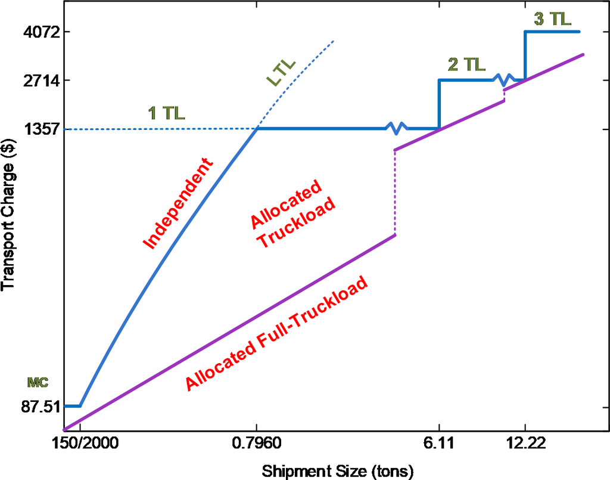

Figure 1: Truck transport-charge function for the Raleigh–Gainesville lane ($d = 532$ mi, $r_\text{TL} = \$2.55/\text{mi}$, $q_{\max} = 6.11$ ton): independent charge (blue, step-shaped in truck count) vs allocated full-truckload charge (purple, linear at $r_\text{FTL} d$ per ton). Labels show $1\!\cdot\!r_\text{TL} d = \$1{,}357$, $2\!\cdot\!r_\text{TL} d = \$2{,}714$, $3\!\cdot\!r_\text{TL} d = \$4{,}072$; minimum charge $MC = \$87.51$.

When it is reasonable to assume that a shipment will always be transported along with other shipments as part of a full truckload, then using $r_\text{FTL}$ as the truckload transport rate for the shipment allows its transport cost to be considered in a location decision without having to know the exact mix of other shipments being transported, and the mix, size, and timing can change with each shipment without impacting the decision since only $f$, the annual demand, is used in the analysis, and its cost per mile for transport is independent of shipment size and distance. The formulation using $w$ is useful in location analysis where monetary weight (*w*) corresponds to the criterion used for the minisum transport-oriented single-facility location problem.

## 4. Total logistics costs

*Total logistics costs* are any of the relevant costs associated with providing a logistics service, where a *relevant cost* is a cost that differs when comparing multiple alternatives and, as such, can be used in making a decision between the alternatives. Total logistics cost decomposes into three such terms:

$$\text{TLC} \;=\; \text{TC} + \text{IC} + \text{PC}, \qquad
\text{IC} \;=\; \text{IC}_\text{working} + \text{IC}_\text{economic} + \text{IC}_\text{safety}.$$

where TC is transport cost, PC is purchase cost, and IC is inventory cost. With respect to transportation, there is almost always a transportation cost component of total logistics cost even for a single origin and destination, since differences in the speed and reliability of transport affect cost. Since it is usually not economic to ship individual units of an item, multiple units are batched together in a single shipment, and unless they are used immediately, those batched units incur an inventory cost for storage while they are consumed. The cost to purchase items can differ if different suppliers are considered, and typically a lower purchase cost for an item is associated with a higher transport cost. Inventory is classified along two independent axes: *role* (why it’s held) and *stage* (where it sits in the materials flow). Any role can occur at any stage; each cell below names the subcategory at that intersection.

Table 1: Inventory classification by role (rows) and materials-flow stage (columns).

| Role | Raw material | Work in process | Finished goods |
| --- | --- | --- | --- |
| **Working stock**: *held as part of the production process* | in-transit from supplier | queuing between operations | in-transit in distribution; presentation stock |
| **Economic stock**: *held to enable cheaper purchase or production* | cycle stock due to shipping truckloads | batch production to spread setup cost | anticipation / seasonal pre-build |
| **Safety stock**: *held to buffer uncertainty* | buffer against supplier delay | decoupling buffer between operations | buffer against demand uncertainty |

$$\text{IC}_\text{cycle} \;=\; \underbrace{vh}_{\text{cost of holding 1 ton 1 yr}}
\;\times\;
\underbrace{\alpha q}_{\text{average inventory level}}.$$

where

**$v$**

unit value of shipment ($/ton)

**$h$**

inventory carrying rate, the cost per dollar of inventory per year (1/yr)

**$q$**

shipment size (ton)

**$\alpha$**

average inter-shipment inventory fraction at origin and destination.

The cost of holding one ton of inventory for one year is $vh$ ($/ton-yr). The inventory carrying rate is expressed as a fraction since the cost per dollar of inventory per year ($/$/yr) reduces to 1/yr.

**Components of** $h$.

$$h = \text{interest} + \text{warehousing} + \text{obsolescence},$$

where

- **Interest** (5%) and **warehousing** (6%)[^1]
- **Obsolescence**: default rate (yr) $h = 0.3 \Rightarrow h_\text{obs} \approx 0.2$ (mfg product)

For most items, interest and warehousing costs are fairly constant while obsolescence cost can differ significantly between items. For *low* FGI cost (yr-scale): $h = h_\text{int} + h_\text{wh} + h_\text{obs}$. For *high* FGI cost (hr-scale): $h \approx h_\text{obs}$, can ignore interest and warehousing, $(h_\text{int} + h_\text{wh})/H = (0.05 + 0.06)/2000 = 0.000055$ ($H$ = operating hr/yr).

Estimate $h_\text{obs}$ using the “percent-reduction interval” method: given time $t_h$ when product loses $x_h$-percent of its original value $v$, find $h_\text{obs}$:

$$h_\text{obs}\,t_h\,v = x_h\,v \;\Rightarrow\; h_\text{obs}\,t_h = x_h \;\Rightarrow\; \boxed{h_\text{obs} = \frac{x_h}{t_h}}, \quad \text{and } t_h = \frac{x_h}{h_\text{obs}}.$$

*Important:* $t_h$ should be in the same time units as $t_{CT}$.

**Example.** If a product loses 80% of its value after 2 hours 40 minutes:

$$t_h = 2 + \frac{40}{60} = 2.67~\text{hr} \;\Rightarrow\; h = \frac{x_h}{t_h} = \frac{0.8}{2.67} = 0.3.$$

**Why** $\alpha = 1$ for constant production and constant consumption.

Since demand is constant throughout the year, one half of a shipment is stored at the destination, on average. Assuming that the production rate is also constant, one half of a shipment will also be stored at the origin, on average. So $\alpha = \alpha_O + \alpha_D = \tfrac{1}{2} + \tfrac{1}{2} = 1$.

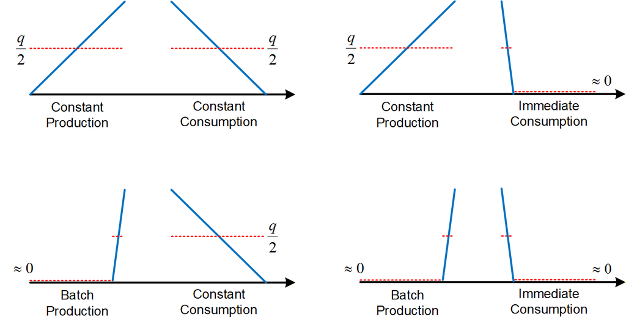

Figure 2: The four production–consumption regimes, with $\alpha_O,\alpha_D$ marked on each. The example here is the top-left panel: $\alpha = 1$.

Table 2: Inventory fraction $\alpha$ for the four production–consumption regimes.

| Regime | $\alpha_O$ | $\alpha_D$ | $\alpha$ |
| --- | --- | --- | --- |
| Constant production / constant consumption | ½ | ½ | **1** |
| Constant production / immediate consumption | ½ | 0 | ½ |
| Batch production / constant consumption | 0 | ½ | ½ |
| Batch production / immediate consumption | 0 | 0 | 0 |

**NoteOther regimes for $\alpha$ (textbook discussion)**

The parameter $\alpha$ denotes the average fraction of the shipment size *q* that is held, in total, across the origin and the destination. For example, assuming that, on an annual basis, the supply and demand rates between a given O-D pair are constant, then, for a shipment of size *q*, the expected cycle inventory is $q/2$ at each end,[^2] meaning that the total cycle inventory across the origin and the destination is *q* and, therefore, $\alpha = 1$; also, if supply is not constant (e.g., batch production) but the time of production is not coordinated with the time of shipment, then $\alpha = 1$ (assuming production is equally likely to have occurred at anytime between shipments). If production at the origin is instantaneous, with a constant demand rate at the destination (i.e., the traditional EOQ model), then $\alpha = 0.5$. If, however, both production and consumption are instantaneous, then $\alpha = 0$ (more on this case below). Finally, if the supplier is another firm and there are no negotiations with the supplier, e.g., to share the benefits of using an optimal shipment size that accounts for the supplier’s inventory costs, then (from the point of view of the shipper-customer) $\alpha = 0.5$. Thus, annual inventory holding costs are given by $\alpha v h q$.

Example 1(d): Cycle inventory cost at FTL

Give a reasonable estimate for the total annual cycle inventory cost at the FTL shipment size $q_{\max}$, with $v = \$25{,}000$/ton, $h = 0.3~\text{yr}^{-1}$, and $\alpha = 1$.

$$\text{IC}_\text{FTL} \;=\; \alpha v h q_{\max}
\;=\; (1)(25{,}000)(0.3)(6.11)
\;=\; \$45{,}833/\text{yr}.$$

```julia
α = 1
v = 25000                   # $/ton
h = 0.3                     # 1/yr
@show IC_FTL = α*v*h*qmax;  # $/yr
```

```
IC_FTL = α * v * h * qmax = 45833.333333333336
```

$IC_\text{FTL} = \$45{,}833/\text{yr}$.

Example 1(e): Total logistics cost at FTL

Combine the transport and inventory costs to obtain the annual total logistics cost (TLC) for full-truckload TL shipments.

$$\text{TLC}_\text{FTL} \;=\; TC_\text{FTL} + \text{IC}_\text{FTL} \;=\; 4{,}442 + 45{,}833 \;=\; \$50{,}275/\text{yr}.$$

```julia
@show TC_FTL IC_FTL
@show TLC_FTL = TC_FTL + IC_FTL;
```

```
TC_FTL = 4441.731433123838
IC_FTL = 45833.333333333336
TLC_FTL = TC_FTL + IC_FTL = 50275.06476645717
```

$TLC_\text{FTL} = \$50{,}275/\text{yr}$.

Transport costs typically decrease with increasing size due to economies of scale associated with providing the transport, while inventory costs increase since more inventory is held when shipment size increases. The optimal shipment size corresponds to the size that minimizes the sum of transport and inventory costs. Selecting the shipment size on the basis of its *TLC* requires that both inventory carrying and transportation costs be specified as a function of $q$. Considering only cycle inventory costs,

$$TLC(q) = TC(q) + IC(q) = \frac{f}{q}\,c(q) + \alpha v h q,$$

with $\alpha$, $v$, and $h$ as defined above.

Example 1(f): Optimal TL shipment size

Allowing shipment sizes less than a full truckload, determine the TL shipment size $q^\star_\text{TL}$ that minimises the annual TLC for TL service, and the resulting $TLC^\star_\text{TL}$.

$$\text{TLC}_\text{TL}(q) \;=\; TC_\text{TL}(q) + IC(q) \;=\; \frac{f}{q}\,c_\text{TL}(q) + \alpha v h q \;=\; \frac{f}{q}\, r_\text{TL} d + \alpha v h q.$$

$$\frac{d\,\text{TLC}_\text{TL}(q)}{dq} = 0 \;\Rightarrow\; q^\star_\text{TL} \;=\; \sqrt{\frac{f r_\text{TL} d}{\alpha v h}}.$$

Including the minimum charge $MC_\text{TL}$ and maximum payload restrictions:

$$q^\star_\text{TL} \;=\; \min\!\left\{\sqrt{\frac{f \max\{r_\text{TL} d,\, MC_\text{TL}\}}{\alpha v h}},\; q_{\max}\right\} \;\approx\; \sqrt{\frac{f r_\text{TL} d}{\alpha v h}}.
\tag{1}$$

```julia
@show qᵒTL    = sqrt((f*rTL*d)/(α*v*h))  # ton
@show TCᵒ_TL  = (f/qᵒTL)*rTL*d           # $/yr
@show ICᵒ_TL  = α*v*h*qᵒTL               # $/yr
@show TLCᵒ_TL = TCᵒ_TL + ICᵒ_TL;         # $/yr
```

```
qᵒTL = sqrt((f * rTL * d) / (α * v * h)) = 1.9024165093737864
TCᵒ_TL = (f / qᵒTL) * rTL * d = 14268.123820303399
ICᵒ_TL = α * v * h * qᵒTL = 14268.123820303397
TLCᵒ_TL = TCᵒ_TL + ICᵒ_TL = 28536.247640606794
```

$q^\star_\text{TL} = 1.90$ ton, $TLC^\star_\text{TL} = \$28{,}536/\text{yr}$.

Example 1(g): Allocated FTL

Including the minimum-charge and maximum-payload restrictions, determine the TLC if a shipment of size $q^\star_\text{TL}$ could be made as an allocated full-truckload (sharing the truck across many shipments).

$$\text{TLC}_\text{AllocFTL}(q^\star_\text{TL}) \;=\; \frac{f}{q^\star} (q^\star r_\text{FTL} d) + \alpha v h q^\star
\;=\; f \frac{r_\text{TL}}{q_{\max}} d + \alpha v h q^\star.$$

```julia
@show TLC_AllocFTL = f*rTL/qmax*d + α*v*h*qᵒTL;  # $/yr
```

```
TLC_AllocFTL = ((f * rTL) / qmax) * d + α * v * h * qᵒTL = 18709.855253427235
```

$TLC_\text{AllocFTL} = \$18{,}709.85/\text{yr}$ (vs. $28,536.25 as independent P2P TL).

Example 1(h): Optimal LTL shipment size

Determine the LTL shipment size $q^\star_\text{LTL}$ that minimises the annual TLC for LTL service.

$$\text{TLC}_\text{LTL}(q) \;=\; \frac{f}{q}\max\{c_\text{LTL}(q),\, MC_\text{LTL}\} + \alpha v h q \;\approx\; f\,r_\text{LTL}(q)\,d + \alpha v h q.$$

This expression cannot be solved in closed form and must be solved numerically:

$$q^\star_\text{LTL} \;=\; \arg\min_{150/2000 \,\le\, q \,\le\, 5} \text{TLC}_\text{LTL}(q).$$

Must be careful in picking bounds for optimization since the LTL formula is only valid for a limited range of values:

$$r_\text{LTL}(q,s,d) \;=\; \text{PPI}_\text{LTL} \cdot \frac{\frac{s^2}{8} + 14}{(q^{1/7} d^{15/29} - \tfrac{7}{2})(s^2 + 2s + 14)},$$

valid over $37 \le d \le 3354$ mi, $0.075 \le q \le 5$ ton, and $2000 q/s \le 650$ ft³, giving $0.075 \le q \le 1.44$ ton.

```julia
ppiLTL = 177.4

TLC_LTLh(q) = (f/q) * rate_ltl(q, s, d; ppi=ppiLTL) * q * d +
              α*v*h*q

@show LB = 150/2000  # ton (lower bound on q)
@show UB = min(5, 650*s/2000)  # ton (upper bound on q)
@show qᵒLTL = optimize(TLC_LTLh, LB, UB).minimizer;  # ton
```

```
LB = 150 / 2000 = 0.075
UB = min(5, (650s) / 2000) = 1.4444444444444446
qᵒLTL = (optimize(TLC_LTLh, LB, UB)).minimizer = 0.7621710347459996
```

$q^\star_\text{LTL} = 0.76$ ton.

Example 1(i): Service choice

Given the optimal TL and LTL shipment sizes, determine which service minimises annual TLC.

```julia
rLTL = rate_ltl(qᵒLTL, s, d; ppi=ppiLTL)
@show rLTL                          # $/ton-mi
@show cLTL     = rLTL * qᵒLTL * d   # $
@show TCᵒ_LTL  = (f/qᵒLTL) * cLTL   # $/yr
@show ICᵒ_LTL  = α*v*h*qᵒLTL        # $/yr
@show TLCᵒ_LTL = TCᵒ_LTL + ICᵒ_LTL  # $/yr

@show TLCᵒ_TL
TLCᵒ_TL > TLCᵒ_LTL ?
    println("LTL selected") : println("TL selected");
```

```
rLTL = 3.228317890509784
cLTL = rLTL * qᵒLTL * d = 1309.002165936596
TCᵒ_LTL = (f / qᵒLTL) * cLTL = 34349.3023550241
ICᵒ_LTL = α * v * h * qᵒLTL = 5716.282760594997
TLCᵒ_LTL = TCᵒ_LTL + ICᵒ_LTL = 40065.58511561909
TLCᵒ_TL = 28536.247640606794
TL selected
```

$TLC^\star_\text{TL} = \$28{,}536/\text{yr}$ vs $TLC^\star_\text{LTL} = \$40{,}066/\text{yr}$, TL is selected at $v=\$25k$.

**NoteWhy minimize TL and LTL separately**

Better to pick from separate optimal TL and LTL because the independent charge has two local minima:

$$q^\star_0 \;=\; \arg\min_q \bigl\{ TLC_\text{TL}(q),\; TLC_\text{LTL}(q) \bigr\}
\quad \text{vs.} \quad
q^\star_0 \;\overset{!}{=}\; \arg\min_q \left\{ \frac{f}{q}\, c_0(q) + \alpha v h q \right\}.$$

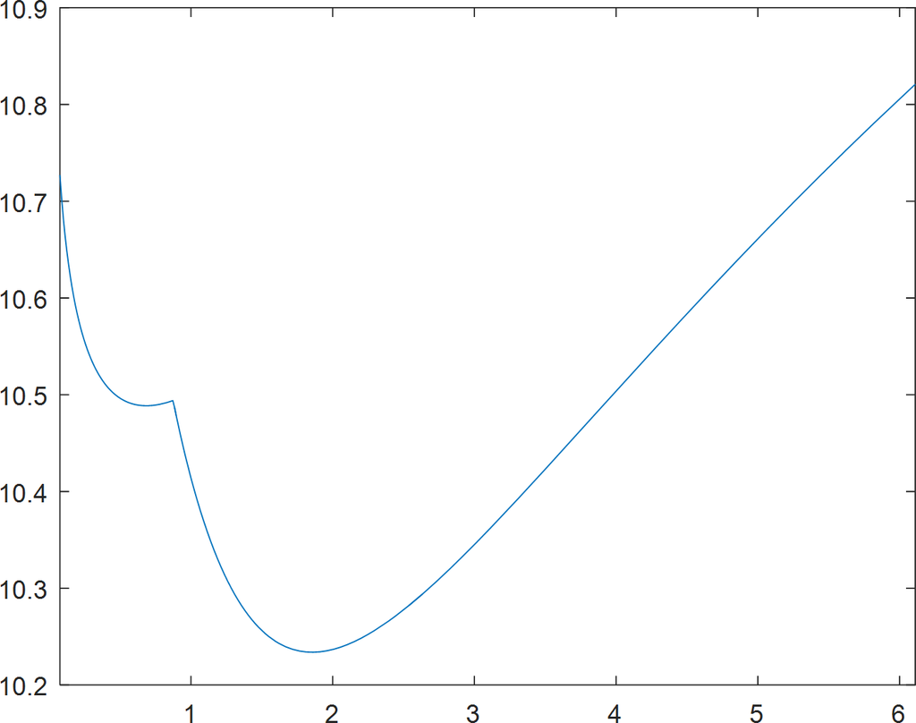

Figure 3: The $v=\$25{,}000$ product (Example 1(i)), where TL is selected: $\ln TLC_0(q)$ has its global minimum at the TL solution, $q^\star \approx 1.9$ ton, with a second-best local minimum at the LTL solution, $q \approx 0.76$ ton.

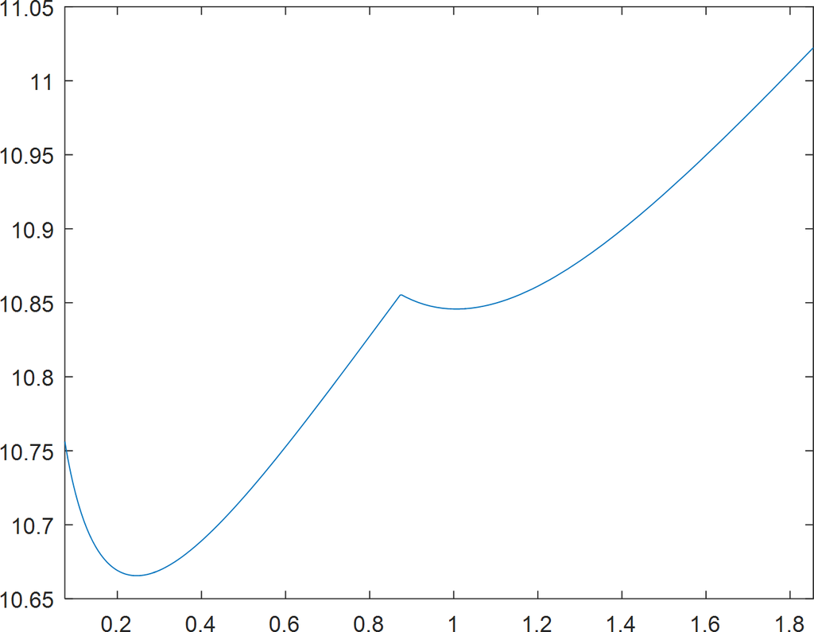

Figure 4: The $v=\$85{,}000$ product (Example 1(j)), where LTL is selected: the global minimum is now the LTL solution, $q^\star \approx 0.27$ ton, and the TL solution ($q \approx 1.0$ ton) is the second-best local minimum; the kink is the TL/LTL crossover.

Figs. 3 and 4 are the lecture’s own two cases: Fig. 3 is the $v=\$25{,}000$ product (Ex. 1(i), TL selected) and Fig. 4 the $v=\$85{,}000$ product (Ex. 1(j), LTL selected), each plotted as $\ln TLC_0(q)$ over the full range of $q$. Fig. 3 has two clear local optimal solutions that differ from the two optimal solutions for Fig. 4: one shows the case where truckload (TL) is better (Fig. 3), the other where LTL is better (Fig. 4). Because the independent charge $c_0(q)$ has a kink at the TL/LTL crossover, traditional univariate nonlinear optimization techniques could get stuck in the second-best local optimal solution. By taking the best of TL and LTL, first the TL is computed directly (analytically), and then the LTL has a single local optimal solution, the resulting procedure is much more robust and better able to find the global optimum, which is what `minTLC` does in Sec. 4.

Example 1(j): Service choice at higher product value

If the unit value of the product rises to $v = \$85{,}000$/ton, re-determine the optimal shipment sizes and which service is selected.

```julia
v = 85000                                           # was 25000

@show qᵒTL    = sqrt((f*rTL*d)/(α*v*h))             # ton
@show TCᵒ_TL  = (f/qᵒTL)*rTL*d                      # $/yr
@show ICᵒ_TL  = α*v*h*qᵒTL                          # $/yr
@show TLCᵒ_TL = TCᵒ_TL + ICᵒ_TL                     # $/yr

@show qᵒLTL = optimize(TLC_LTLh, LB, UB).minimizer  # ton
rLTL = rate_ltl(qᵒLTL, s, d; ppi=ppiLTL)
@show rLTL                                          # $/ton-mi
@show cLTL     = rLTL * qᵒLTL * d                   # $
@show TCᵒ_LTL  = (f/qᵒLTL) * cLTL                   # $/yr
@show ICᵒ_LTL  = α*v*h*qᵒLTL                        # $/yr
@show TLCᵒ_LTL = TCᵒ_LTL + ICᵒ_LTL                  # $/yr
TLCᵒ_TL > TLCᵒ_LTL ?
    println("LTL selected") : println("TL selected");
```

```
qᵒTL = sqrt((f * rTL * d) / (α * v * h)) = 1.0317302108505633
TCᵒ_TL = (f / qᵒTL) * rTL * d = 26309.12037668936
ICᵒ_TL = α * v * h * qᵒTL = 26309.120376689363
TLCᵒ_TL = TCᵒ_TL + ICᵒ_TL = 52618.24075337872
qᵒLTL = (optimize(TLC_LTLh, LB, UB)).minimizer = 0.2735447301881209
rLTL = 3.836994200243633
cLTL = rLTL * qᵒLTL * d = 558.3816370031636
TCᵒ_LTL = (f / qᵒLTL) * cLTL = 40825.618290592254
ICᵒ_LTL = α * v * h * qᵒLTL = 6975.390619797084
TLCᵒ_LTL = TCᵒ_LTL + ICᵒ_LTL = 47801.00891038934
LTL selected
```

$TLC^\star_\text{LTL} = \$47{,}801/\text{yr}$ vs $TLC^\star_\text{TL} = \$52{,}618/\text{yr}$, at higher product value, LTL is selected (smaller $q^\star$, more frequent shipments).

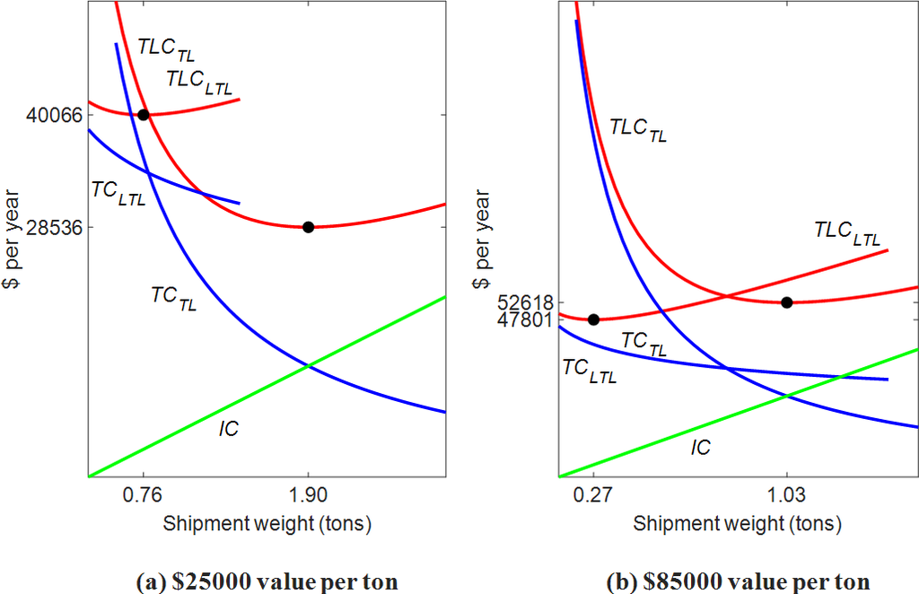

Figure 5: Service-choice curves at two product values. (a) $v=\$25{,}000$/ton: $TLC^\star_\text{TL} = 28{,}536 < TLC^\star_\text{LTL} = 40{,}066$ at $q^\star_\text{TL} = 1.90$; TL is selected. (b) $v=\$85{,}000$/ton: $TLC^\star_\text{LTL} = 47{,}801 < TLC^\star_\text{TL} = 52{,}618$ at $q^\star_\text{LTL} = 0.27$; LTL is selected. As $v$ rises, the IC line (green) steepens, shrinking $q^\star$ and shifting which service is selected.

Up until this point, only one product has been handled. The most important idea when shipping multiple products together is that all of the products can be treated as a single *aggregate* product: every formula for the optimal shipment size of a single product carries over to the aggregate product, with each model parameter replaced by its aggregate counterpart. This aggregate shipment typically never occurs in practice because there might be thousands of different potential items; instead, different small subsets of these items would comprise each actual load that is transported over the course of a year.

We package the per-shipment parameters into a DataFrame row and the carrier parameters into a NamedTuple:

```julia
tr = (r = rTL, Kwt = 25, Kcu = 2750, ppi = ppiTL)
# :a matches Logjam; math is αvh
sh = DataFrame(f=f, s=s, a=α, v=v, h=h, d=d);
```

`minTLC(sh, tr [, ppi])` returns a NamedTuple `(qᵒ, TLCᵒ, isLTL)`, the cost-minimising shipment size, the resulting TLC, and a Boolean indicating whether LTL was chosen, for a single shipment row, letting the next two questions stay short.

Example 1(k): A second product

On Jan 10, 2018, determine the optimal independent shipment size and TLC for a second product, 80 tons/yr of Class-60 material worth $5,000/ton, shipped on the same Raleigh-to-Gainesville lane.

A Class-60 product worth $5,000/ton, 80 tons/yr, same Raleigh-to-Gainesville lane:

```julia
push!(sh, first(sh))                     # duplicate the row
sh[2, [:f, :s, :v]] = [80, 32.16, 5000]  # patch the second product
sh.qmax = [maxpayld(row, tr) for row in eachrow(sh)]
transform!(sh, AsTable(:) =>
    ByRow(row -> minTLC(row, tr, ppiLTL)) => AsTable)
prt(sh)
```

```
    f      s  a       v       h    d   qmax    qᵒ       TLCᵒ  isLTL
───────────────────────────────────────────────────────────────────
1  20   4.44  1  85,000  0.3000  532   6.11  0.27  47,801.01      1
2  80  32.16  1   5,000  0.3000  532  25.00  8.51  25,523.60      0
```

Class-60 product: $q^\star = 8.51$ ton, $TLC^\star_\text{TL} = \$25{,}524/\text{yr}$.

## 5. Aggregate periodic shipment

Since for periodic shipments *q* is not given and must be determined, *f* can be used in place of *q* when determining the aggregate demand and density of multiple items shipped together as part of a single load. The aggregate value is the demand-weighted sum of the values of the items:

$$f_\text{agg} = \sum f_i,\quad
s_\text{agg} = \frac{f_\text{agg}}{\sum f_i/s_i},\quad
v_\text{agg} = \frac{\sum f_i v_i}{f_\text{agg}}.$$

Example 1(l): Aggregate shipment

Determine the annual TLC if the two products are always shipped together on the same truck, and compare to the sum of their independent TLCs.

For this example, with $d_1 = d_2$, $h_1 = h_2$, and $\alpha_1 = \alpha_2$:

$$\begin{aligned}
f_\text{agg} &= 20 + 80 = 100~\text{ton} \\
s_\text{agg} &= \frac{100}{20/4.44 + 80/32.16} = 14.31~\text{lb/ft}^3 \\
v_\text{agg} &= \tfrac{20}{100}(85{,}000) + \tfrac{80}{100}(5{,}000) = \$21{,}000/\text{ton} \\
q^\star_{TL} &= \sqrt{\frac{f_\text{agg}\, r_\text{TL}\, d}{\alpha\, v_\text{agg}\, h}}
= \sqrt{\frac{100 \,(2.5511)\,(532)}{(1)(21{,}000)(0.3)}}
= 4.6414~\text{ton}.
\end{aligned}$$

```julia
ash = combine(sh,
    :f => sum => :f,
    [:f, :s] => ((f, s) -> sum(f)/sum(f ./ s)) => :s,
    [:f, :a] => ((f, a) -> sum(f .* a) / sum(f)) => :a,
    [:f, :v] => ((f, v) -> sum(f .* v) / sum(f)) => :v,
    [:f, :h] => ((f, h) -> sum(f .* h) / sum(f)) => :h,
    :d => first => :d)

ash.qmax = [maxpayld(row, tr) for row in eachrow(ash)]
transform!(ash, AsTable(:) =>
    ByRow(row -> minTLC(row, tr)) => AsTable)

@show TLC_indep = sum(sh.TLCᵒ)  # $/yr
@show TLC_agg   = ash.TLCᵒ[1];  # $/yr
```

```
TLC_indep = sum(sh.TLCᵒ) = 73324.60472925525
TLC_agg = ash.TLCᵒ[1] = 58481.90492370572
```

Table 3: Independent vs aggregated shipment economics for the two-product example.

|  | $f$ | $s$ | $v$ | $q_\text{max}$ | TLC | $q^\star$ | $t$ |
| --- | --- | --- | --- | --- | --- | --- | --- |
| 1 | 20 | 4.44 | 85,000 | 6.11 | 47,801.01 | 0.27 | 5.00 |
| 2 | 80 | 32.16 | 5,000 | 25.00 | 25,523.60 | 8.51 | 38.84 |
| 1+2 |  |  |  |  | 73,324.60 |  |  |
| Aggregate | 100 | 14.31 | 21,000 | 19.68 | 58,481.90 | 4.64 | 16.95 |

(Cycle time $t = (q^\star / f) \times 365.25$ days; $f$ in ton/yr, $v$ in $/ton, $q$/$q_\text{max}$ in ton, $s$ in lb/ft³, $TLC$ in $/yr.)

Independent total: $73,325/yr. Aggregated: $58,482/yr. Consolidation saves $14,843/yr.

## 6. Locating a facility with full truckloads

Section 3 noted that when a shipment always moves as part of a full truckload, its monetary weight $w = n\,r = (f/q_{\max})\,r$ ($/mi) is the criterion for the minisum transport-oriented single-facility location problem. Because $w$ depends only on the annual demand $f$ and the maximum payload $q_{\max}$, and not on the shipment size or the distance, it is known before any location is chosen. With the rate $r$ common to every flow, the monetary weights are proportional to the truckload counts $n$, so the facility that minimizes total transport cost is the one minimizing $\sum_i n_i\,d_i$, found from the truckload counts and locations alone, without computing any transport cost. Were the shipments not full truckloads, the optimal size $q^\star$ would itself depend on distance, coupling the size and location decisions and making the objective nonlinear.

Distances are approximated by the great-circle distance $d_\text{gc}$. For transport cost, $d_\text{gc}$ is multiplied by a circuity factor of $1.2$ to approximate continental-U.S. road distance; because this factor is constant, it scales every cost equally and so does not affect the optimal location, only the cost.

Example 2: Locating a production plant

A single product is manufactured at a plant whose location is to be determined. The plant ships full truckloads of finished product to six customers and receives full truckloads of four raw materials from four suppliers. Determine the city of at least 50,000 people in which to locate the plant, and the effect on transport cost of requiring at-least-biweekly customer delivery.

The product ships in units weighing 175 lb and occupying 38.2 ft³; each unit requires 4, 1, 1, and 1 units of raw material from suppliers in Richmond, CA, Canton, OH, Malden, MA, and Tyler, TX, whose units weigh 8, 14, 4, and 29 lb and occupy 2.7, 1.3, 2.7, and 3.6 ft³. Each truck holds 25 ton and 2,750 ft³, and 2,600, 2,200, 700, 700, 600, and 700 units are shipped each year to customers in ZIP codes 87301, 88101, 73099, 72118, 55408, and 15010. All transport is point-to-point full truckloads.

Example 2(a): Full-truckload location

With every shipment a full truckload, determine the city (population at least 50,000) in which to locate the plant.

```julia
Kwt, Kcu = 25, 2750  # truck weight (ton) & cube (ft³) caps

# Finished product, 175 lb & 38.2 ft³ per unit; FTL to customers
sFG = 175/38.2                                           # lb/ft³
@show qmaxFG = maxpayld(sFG; Kwt=Kwt, Kcu=Kcu)           # ton/TL
custZIP = [87301, 88101, 73099, 72118, 55408, 15010]
ud      = [2600, 2200, 700, 700, 600, 700]               # units/yr
wout = (ud .* 175 ./ 2000) ./ qmaxFG  # TL/yr per customer

# Raw materials: full truckloads in from each supplier
supName = ["Richmond", "Canton", "Malden", "Tyler"]
supST   = [:CA, :OH, :MA, :TX]
nin, nout = length(supName), length(custZIP)  # suppliers, customers
wt  = [8, 14, 4, 29]                                     # lb/unit
cu  = [2.7, 1.3, 2.7, 3.6]                               # ft³/unit
BOM = [4, 1, 1, 1]  # raw units per finished unit
qmaxRaw = maxpayld.(wt ./ cu; Kwt=Kwt, Kcu=Kcu)          # ton/TL
fin = (BOM .* sum(ud)) .* wt ./ 2000  # ton/yr from suppliers
win = fin ./ qmaxRaw  # TL/yr from each supplier

# Geolocate the ten endpoints (loc2lonlat); weight w ∝ truckloads
locs = vcat([loc2lonlat(supName[i]; state=supST[i]) for i in 1:nin],
            [loc2lonlat(string(z)) for z in custZIP])
XY = hcat([r.LON for r in locs], [r.LAT for r in locs])  # n×2
w  = vcat(win, wout)
role = [fill("supplier", nin); fill("customer", nout)]
flows = DataFrame(place = vcat(supName, string.(custZIP)),
                  role = role,
                  qmax = vcat(qmaxRaw, fill(qmaxFG, nout)),
                  nFTL = w)
prt(flows; title="full truckloads to/from the plant (TL/yr)")

# Minisum over wᵢ·dgc, then snap to a city of pop ≥ 50,000
x0 = vec(sum(XY, dims=1)) ./ size(XY, 1)  # centroid (any dim)
sumwd(p, w) = sum(w[i]*dgc(p, XY[i, :])
                  for i in 1:size(XY, 1))
locate(w) = lonlat2loc(
    Optim.minimizer(optimize(p -> sumwd(p, w), x0)),
    filter(r -> r.POP >= 50_000 && r.ISCUS, usplace()))
plant = locate(w)
@show (plant.NAME, plant.ST);
```

**1**

`sum(expr for i in ...)` is a *generator* handed straight to `sum`: each weighted distance $w_i\,d_\text{gc}(p, XY_i)$ is produced lazily and accumulated, with no intermediate array allocated. It is the idiomatic Julia spelling of $\sum_i w_i d_i$.

```
qmaxFG = maxpayld(sFG; Kwt = Kwt, Kcu = Kcu) = 6.299083769633508
full truckloads to/from the plant (TL/yr)
     place      role   qmax   nFTL
──────────────────────────────────
  Richmond  supplier   4.07  29.45
    Canton  supplier  14.81   3.55
    Malden  supplier   2.04   7.36
     Tyler  supplier  11.08   9.82
     87301  customer   6.30  36.12
     88101  customer   6.30  30.56
     73099  customer   6.30   9.72
     72118  customer   6.30   9.72
     55408  customer   6.30   8.33
     15010  customer   6.30   9.72
(plant.NAME, plant.ST) = ("Amarillo", :TX)
```

Plant located in **Amarillo, TX**.

Example 2(b): Effect of biweekly delivery

Determine how the optimal location and the annual transport cost change if every customer delivery must be made at least once every two weeks. Use a January 2018 TL PPI of 131.0.

Customer flows shipping fewer than $n_{\min} = 365.25/14 \approx 26$ full truckloads a year cannot hold a two-week interval as full loads, so each is floored to 26 shipments; the two larger New Mexico customers and all inbound supplier flows are unaffected. The constrained truckload counts re-weight the location and raise the transport cost:

```julia
# Customer deliveries at least biweekly: floor OUTBOUND only
nmin = 365.25/14                  # min TL/yr at a 2-week interval
flows.n = [r == "customer" ? max(nf, nmin) : nf
           for (r, nf) in zip(flows.role, flows.nFTL)]
prt(flows; title="biweekly floor on customers (nFTL → n)")

plant2 = locate(flows.n)  # re-optimize with constrained weights
@show (plant2.NAME, plant2.ST)
rA = loc2lonlat(plant.NAME;  state=plant.ST)
rB = loc2lonlat(plant2.NAME; state=plant2.ST)
A = [rA.LON, rA.LAT]; B = [rB.LON, rB.LAT]
@show move_mi = dgc(A, B)

rTL = 2*131.0/102.7               # $/mi (Jan 2018 TL PPI)
TC(c, w) = rTL * sum(w[i]*1.2*dgc(c, XY[i, :])
                     for i in 1:size(XY, 1))
@show TC_ftl = TC(A, flows.nFTL)  # FTL
@show TC_con = TC(B, flows.n)     # biweekly
@show cost_impact = TC_con - TC_ftl
@show reloc_saving = TC(A, flows.n) - TC_con;
```

```
biweekly floor on customers (nFTL → n)
     place      role   qmax   nFTL      n
─────────────────────────────────────────
  Richmond  supplier   4.07  29.45  29.45
    Canton  supplier  14.81   3.55   3.55
    Malden  supplier   2.04   7.36   7.36
     Tyler  supplier  11.08   9.82   9.82
     87301  customer   6.30  36.12  36.12
     88101  customer   6.30  30.56  30.56
     73099  customer   6.30   9.72  26.09
     72118  customer   6.30   9.72  26.09
     55408  customer   6.30   8.33  26.09
     15010  customer   6.30   9.72  26.09
(plant2.NAME, plant2.ST) = ("Enid", :OK)
move_mi = dgc(A, B) = 237.14848093831023
TC_ftl = TC(A, flows.nFTL) = 300348.19238425884
TC_con = TC(B, flows.n) = 434620.63604499196
cost_impact = TC_con - TC_ftl = 134272.44366073312
reloc_saving = TC(A, flows.n) - TC_con = 9738.23370258871
```

Biweekly customer delivery relocates the plant 237 mi to **Enid, OK** and raises transport cost by **$134,272/yr**; re-optimizing there rather than staying in Amarillo saves **$9,738/yr**.

## Endnotes

[^1]: CSCMP’s 33rd Annual *State of Logistics Report*, as reported in John Schulz, “State of Logistics 2022: Out of sync,” *Logistics Management*, 2022.
[^2]: Hall, R.W., 1985, “Dependence between shipment size and mode in freight transportation,” *Transportation Science* 19(4):436–444.